# Northern Three Spatial Analyses (Habitat: Broad Vegetation Groups)

- Show All Code
- Hide All Code
- View Source

Author

Adam Shand

Published

September 7, 2023

**R Version**

For R session info at the time of rendering this script see Section 6.

# 1 Introduction

This script contains the methods used to wrangle, analyse and present broad vegetation group data in the Northern Three regions. For a guide on downloading broad vegetation group data refer to the README document for the Spatial Analysis GitHub repo. Note that broad vegetation group data is actually a subset of regional ecosystem data, and thus only regional ecosystem data needs to be downloaded.

Broad vegetation group data is currently not used in the technical report, however may potentially be used in the future to provide additional basin context, and to help “set the scene” for each basin in each region. broad vegetation group data is currently not scored, and is only a contextual dataset. The main objectives of this script are to:

# 2 Script Set Up

This script requires multiple core spatial packages, all packages are loaded below.

```r
library(sf)
library(tmap)
library(glue)
library(here)
library(terra)
library(tidyverse)
library(grid)
```

We also need to set up key variables for the script such as where we are going to save the outputs, and what coordinate reference system (crs) we are going to be using. Note that the crs is first established under ‘params’ at the start of the script.

```r
#set project variables: crs factor and current_fyear
proj_crs <- params$project_crs

#create a file path to help with saving things
save_path <- here("outputs/n3_habitat_broad-vegetation-groups/")

#bring that path to life
dir.create(save_path)

#create an extra off of this for maps and plots
dir.create(glue("{save_path}/maps/"))
dir.create(glue("{save_path}/plots/"))

#turn off spherical geometry
sf_use_s2(F)

#turn off scientific notation
options(scipen = 999)
```

# 3 Load Data

Now the script is set up we need to load in all of the required datasets. This will be broken into two segments: - Spatial data specific to the N3 region - such as the region, basin, and sub basin boundaries. - Broad Vegetation Group data (which is really just RE data).

## 3.1 Spatial Data

Spatial data for the northern three regions should be readily available in the repo, the dataset is created by the n3_region-builder.qmd script in the repo that should be the first script run for new users. If the dataset is not available refer back to the README document in the GitHub repo. The other parts of spatial data here should go off without a hitch if the region-builder script has been run.

```r
#read in the northern three spatial files and reduce down to only the components we need
n3_region <- st_read(here("data/n3_region-builder/n3_region.gpkg")) |> filter(environment != "Marine") |>
  group_by(region, environment, basin_or_zone, sub_basin_or_sub_zone) |> summarise(geom = st_union(geom)) |>
  rename(basin = basin_or_zone, sub_basin = sub_basin_or_sub_zone) |> ungroup() |>
  st_cast() |> st_make_valid()

#load a queensland outline from the aims package
qld <- get(data("gbr_feat", package = "gisaimsr")) |> filter(FEAT_NAME %in% c("Mainland", "Island")) |>
  st_transform(proj_crs)
```

## 3.2 Broad Vegetation Groups (Obtained Using Regional Ecosystem Data)

**Note**

Broad Vegetation Group data is obtained from the Regional Ecosystem dataset - it is a broader group classification of the same data.

**Note**

This section of the code takes a significant chunk of time to run. Processes have been put in place to reduce the need to rerun this step, however the inclusion of any new regional ecosystem layers as they are published will need to be run through this step.

**Note**

Only the newest and oldest RE layers are provided by QSpatial. If middle layers are missing, refer to README regarding download all layers. Note that the middle layers are not necessarily required for the script to run, but certain outputs benefit from the inclusion of additional layers.

Regional ecosystem (RE) data (i.e. vegetation) is published to QSpatial by DES and covers the entirety of Queensland (for more info can go [here](https://www.qld.gov.au/environment/plants-animals/plants/ecosystems/descriptions)). Vegetation type is given via an RE code such as “11.1.3” where:

- 11 = bioregion (e.g. The Brigalow Belt).
- 1 = landzone (e.g. Tidal flats and beaches).
- 3 = vegetation community (e.g. Sedgelands on marine clay plains).

Regional Ecosystem data is used by multiple scripts under the “habitat” banner in this repo. Because data is frequently used the raw data is stored in a generic data folder that is accessible by all habitat scripts. This is an exception to general repo data storage rules and is noted as such in the README.

### 3.2.1 Getting the Data

The following code chunk executes a few key steps all at once, this is because running each of these steps takes a significant chunk of time and we can create an if-else statement that skips every single step if it has already been done. Some of these steps are quite detailed so we will spend some time here explaining each process. I have tried to highlight each step that is known to take a long time, here we will:

1. Load the raw RE data and create the initial cropped versions of each layer. **Takes a long time.**
   - Behind the scenes this will check if the cropped files already exists to save additional time.
2. Combine each dataset together to form one large dataset called `re_data`.
3. Select the dominant BVG and create custom groupings for each. (See table below).
4. Calculate the area in km2 of each geometry (row) in the dataset **Takes a long time.**
5. Union together all polygons belonging to the same group to improve the look of maps **Takes a long time.**
6. Save the dataset to the bvg folder to make the script run faster next time.

This code chunk **will work no matter how many RE layers are in the folder.** However, this means that for n number of layers in the folder, the chunk will always load n layers. This can reduce the speed of the chunk particularly if you are only interested in the first and layer years.

```r
#create paths to where the final set of bvg data will be saved
path1 <- here("data/n3_habitat_broad-vegetation-groups/broad_vegetation_groups.gpkg")

if (file.exists(path1)){#if dataset exists, read it in and skip everything else

  bvg_map_data <- st_read(path1)

  #add units that were wiped during the save
  bvg_map_data$area <- units::set_units(bvg_map_data$area, km^2)

} else {#begin the process of creating the files

  #read in northern three spatial files and reduce down to a slightly different version than the one above
  n3_bvg_boundary <- st_read(here("data/n3_region-builder/n3_region.gpkg")) |> filter(environment != "Marine") |>
    group_by(region, basin_or_zone, sub_basin_or_sub_zone) |> summarise(geom = st_union(geom)) |>
    rename(basin = basin_or_zone, sub_basin = sub_basin_or_sub_zone) |>
    ungroup() |> st_cast() |> st_make_valid()

  #get/set path to the raw layers and the edited layers
  raw_path <- here("data/n3_habitat/re_raw/")
  cropped_path <- here("data/n3_habitat_broad-vegetation-groups/re_broad_vegetation_groups_cropped/")

  #get list of files in the raw folder that contain "re_" and .gpkg" without their extension
  file_list <- tools::file_path_sans_ext(list.files(raw_path, pattern = ".gpkg"))

  #create a vector to track objects created
  years_loaded <- c()

  for (i in file_list){#for each file in list

    if (file.exists(glue("{cropped_path}/{i}_cropped.gpkg"))){#if the cropped version exists
      writeLines("\n\nCropped file exists, data loaded from storage.\n")

      #read it in
      re_layer <- st_read(glue("{cropped_path}/{i}_cropped.gpkg"))

      #edit the name
      i <- str_remove_all(i, "^re_|_v12_2")

      #keep track of the new object names
      years_loaded <- append(years_loaded, i)

      #assign it to the global environment
      assign(i, re_layer)

    } else {#otherwise load in the raw version and crop it
      writeLines("\nCropped file does not exists, data will be cropped, saved, then loaded.\n")

      #read in the original regional ecosystem layer
      re_layer <- st_read(glue("{raw_path}/{i}.gpkg"))

      #and separate the data into "standard" geometries - polygons, and non-standard geometries - e.g. multisurfaces
      standard_geoms <- re_layer |> filter(grepl("POLYGON", st_geometry_type(geom))) |> st_make_valid()
      non_standard_geoms <- re_layer |> filter(grepl("MULTISURFACE", st_geometry_type(geom)))

      #save non-standard geoms to be edited
      st_write(non_standard_geoms, glue("{cropped_path}/temporary_storage.gpkg"), delete_dsn = T)

      #use the gdalUtilies to open edit and save the file (it auto saves as a folder containing a shapefile)
      gdalUtilities::ogr2ogr(glue("{cropped_path}/temporary_storage.gpkg"), glue("{cropped_path}/temporary_storage"),
                             explodecollections = T, nlt = 'CONVERT_TO_LINEAR', overwrite = T)

      #read back in the edited file
      fixed_geoms <- st_read(glue("{cropped_path}/temporary_storage/temporary_storage.shp")) |>
        rename(geom = geometry) |> st_make_valid() |> rename(Shape_Length = Shape_Leng)

      #join the fixed data onto the standard data
      re_layer <- rbind(standard_geoms, fixed_geoms)

      #transform the crs, then intersect over the bvg area
      re_layer <- re_layer |> st_transform(proj_crs) |> st_intersection(n3_bvg_boundary)

      #save the file
      st_write(re_layer, glue("{cropped_path}/{i}_cropped.gpkg"), append = F)

      #edit the name
      i <- str_remove_all(i, "^re_|_v12_2")

      #keep track of the new object names
      years_loaded <- append(years_loaded, i)

      #assign it to the global environment
      assign(i, re_layer)

    }

  }

  #clean up
  rm(re_layer)

  for (i in years_loaded){#create a year column then assign it to the correct name again
    writeLines("\nAssigning layer years.")

    #get the specific layer and add the year
    data <- get(i) |> mutate(year = i) |> select(-any_of(c("OBJECTID", "Shape_Length", "Shape_Area")))

    #reassign data to the correct name
    assign(i, data)

  }

  #create a list containing all of the datasets that were loaded in
  data_set_list <- lapply(years_loaded, function(x) get(x))

  #bind all datasets together
  writeLines("\nBinding data.\n")
  re_data <- do.call(rbind, data_set_list)

  #clean up
  rm(list = years_loaded, data_set_list)
  gc()

  #select columns we want, create custom vegetation names, extract only polygons, and calculate area of all polygons
  bvg_map_data <- re_data |> select(region, basin, sub_basin, year, DBVG5M) |>
    mutate(vegetation = case_when(DBVG5M == 1 ~ "Rainforest and Scrubs",
                                  DBVG5M %in% c(2, 3, 4, 5, 6) ~  "Eucalypt Variations",
                                  DBVG5M == 7 ~ "Callitris Woodland",
                                  DBVG5M == 8 ~ "Melaleuca Open Woodlands",
                                  DBVG5M %in% c(9, 10) ~ "Acacia Dominated",
                                  DBVG5M == 11 ~ "Mixed Species Woodlands",
                                  DBVG5M == 12 ~ "Other Coastal Communities",
                                  DBVG5M == 13 ~ "Tussock Grasslands",
                                  DBVG5M == 14 ~ "Hummock Grasslands",
                                  DBVG5M == 15 ~ "Wetlands",
                                  DBVG5M == 16 ~ "Mangroves and Saltmarshes",
                                  DBVG5M == "non-remnant" ~ "Non-Remnant Vegetation",
                                  DBVG5M == "water" ~ "Water",
                                  DBVG5M == "plantation" ~ "Plantation",
                                  T ~ NA))

   #create look up to optionally rename the geometry column
  lookup <- c(geom = "Shape")

  #rename if needed
  bvg_map_data <- bvg_map_data |> rename(any_of(lookup))

  #union features to improve map visibility then calculate area
  writeLines("\nUnioning features and calculating area.\n")
  bvg_map_data <- bvg_map_data |> group_by(region, basin, sub_basin, year, vegetation) |>
    summarise(geom = st_union(geom)) |> ungroup() |> mutate(area = st_area(geom))

  #update units on area
  bvg_map_data$area <- units::set_units(bvg_map_data$area, km^2)

  #save the file
  st_write(bvg_map_data, path1, delete_dsn = T)

  #clean up and force a garbage collection
  rm(re_data)
  gc()

}
```

[output not shown]

*These aren’t present in the N3 region after cutting to the basins only.

# 4 Analyse Data

Once we have boiled down the vegetation to the specific groups we want we can begin the analysis. Currently we are looking to calculate:

- The total area coverage by each bvg type in each basin for each year.
- The proportion of the total area that each vegetation covers.
- The change year on year of each vegetation.

## 4.1 Calculate Total Vegetation Coverage and Proportional Coverage

Here we can group by region basin and year to get total cover, then use rowwise to divide by each vegetation type, and then group by the custom re to get a final sum and percent for each re in each basin in each year.

```r
#calculate the total area of each basin for each year and the proportion each vegetation covers
bvg_tbl_data <- bvg_map_data |> st_drop_geometry() |>
  group_by(region, basin, sub_basin, year) |> mutate(total_basin_area = sum(area)) |>
  ungroup() |>
  rowwise() |> mutate(percent_coverage = as.numeric((area/total_basin_area)*100)) |>
  ungroup() |>
  group_by(region, basin, sub_basin, year, total_basin_area, vegetation) |>
  summarise(area = sum(area),
            percent_coverage = sum(percent_coverage)) |>
  ungroup()
```

## 4.2 Calculate Year on Year Change

After calculating the area each vegetation types covers (and had previously covered) we can then do a year on year comparison to track the loss/gain over time. A good trick here is to order by vegetation type, so we can then use the lag() function to query the above row.

```r
#create a set of rows for non remnant vegetation in the pre clear year (this is obviously 0 but helps with calculations below)
non_rem_tbl <- bvg_tbl_data |> filter(year == "pre_clear") |> distinct(sub_basin, .keep_all = T) |>
  mutate(area = 0, percent_coverage = 0, vegetation = "Non-Remnant Vegetation")

#add units to temp table
non_rem_tbl$area <- units::set_units(non_rem_tbl$area, km^2)

#bind these new rows to the main data
bvg_tbl_data <- bind_rows(bvg_tbl_data, non_rem_tbl)

#create a 0 value with units
replace_value <- units::set_units(0, km^2)

#order by RE type, group by basin and RE, then compare the row to the one above using lag(), replace na values with 0
bvg_tbl_data <- bvg_tbl_data |> arrange(sub_basin, vegetation, year) |>
  group_by(basin, sub_basin, vegetation) |>
  mutate(y_on_y_area_change = area - lag(area),
         y_on_y_percentage_change = percent_coverage - lag(percent_coverage)) |>
  mutate(across(matches("percent"), \(x) replace_na(x, 0)),
         across(matches("area"), \(x) replace_na(x, replace_value)),
         across(where(is.numeric), \(x) round(x, 5))) |>
  ungroup()
```

Once that is done we can save the full table to the outputs folder.

```r
#save full table
write.csv(bvg_tbl_data, glue("{save_path}/bvg_full_table.csv"))
```

## 4.3 Create Summary Table

Even when looking at only the 14 custom BVG groups, that can still be a bit much to quickly review. So here we will also create a cut down summary table that highlights the top 5 BVGs in each basin.

```r
#select top 5
bvg_top_5 <- bvg_tbl_data |> arrange(desc(area)) |>
  group_by(basin, year) |> slice(1:5) |> ungroup()

#save full table
write.csv(bvg_top_5, glue("{save_path}/bvg_top_5.csv"))
```

# 5 Visualise Data

In this section we will create a few visualizations:

- A horizontal stacked bar chart of the proportional coverage of each BVG group in each basin.
- A map of BVG groups in each basin
- A bar chart of percentage change over time

## 5.1 Horizontal Stacked Bar Chart

The horizontal stacked bar chart will make use of the table version of the data as there is no spatial information required. First we will create a custom palette that ggplot will use as a reference for how to color groups.

```r
#create custom palette: Acacia, Callitris, Eucalypt, Hummock, Mangroves, Melaleuca, Mixed, Non, Other, Plantation, Rainforest, Tussock, Water, Wetlands
my_palette <- c("#FFBD5B", "#CCCC00", "#846030", "#FF9999", "#2A7E54", "#D5B58B", "#B8E08C",
                "#B83D00", "#00C5C0", "#8C3FC5", "#004600", "#FFD597", "#75DBFF", "#3C6ABE")

#assign names to my palette so ggplot can colour everything correctly
names(my_palette) <- sort(unique(bvg_tbl_data$vegetation))
```

Then we will create the plots, looping for each basin and each year. Note that the way the palette works is by matching the names of the palette variable we created to the cell values in the vegetation column.

```r
#list out basins
sub_basins <- unique(n3_region$sub_basin)

#get the newest year
target_year <- tail(sort(unique(bvg_tbl_data$year)),1)

for (i in sub_basins){#for each basin

  #select a specific basin and arrange the data appropriately
  sub_basin_plot <- bvg_tbl_data |> filter(sub_basin == i, year == target_year) |>
    arrange(desc(percent_coverage)) |>
    mutate(vegetation = factor(vegetation, levels = unique(vegetation)))

  if (nrow(sub_basin_plot) != 0){

    #create a plot
    plot <- ggplot(sub_basin_plot, aes(fill = vegetation, x = sub_basin, y = percent_coverage)) +
      geom_bar(position = position_fill(reverse = T), stat = "identity") +
      scale_fill_manual(values = my_palette) +
      scale_x_discrete(expand = c(0.025, 0)) +
      scale_y_continuous(expand = c(0, 0), labels = scales::percent_format(accuracy = 1)) +
      labs(x = "", y = "", fill = glue("{i} \nBroad Vegetation Groups")) +
      theme(axis.text.x = element_text(colour = "black"),
            axis.text.y = element_blank(),
            axis.line.x = element_line(colour = "black"),
            axis.ticks.length = unit(-0.15, "cm"),
            panel.background = element_blank()) +
      coord_flip()

    #edit names
    edit_i <- str_remove_all(str_to_lower(paste(i, target_year, sep = "_")), "_tbl")

    #save
    ggsave(glue("{save_path}/plots/{edit_i}_broad_vegetation_groups_plot.png"), plot, width = 12, height = 4)

    if (unique(sub_basin_plot$sub_basin) != unique(sub_basin_plot$basin)){#if sub basin != basin

      #figure out what the basin actually is
      actual_basin <- unique(sub_basin_plot$basin)

      #edit name for file editing
      basin_name <- str_replace_all(str_to_lower(actual_basin), " ", "_")

      if (!file.exists(glue("{save_path}/plots/{basin_name}_basin_broad_vegetation_groups_plot.png"))){

        #select a specific basin and arrange the data appropriately
        sub_basin_plot <- bvg_tbl_data |> filter(basin == actual_basin, year == target_year) |>
          group_by(region, basin, vegetation) |> summarise(area = sum(area)) |>
          group_by(region, basin) |> mutate(total_basin_area = sum(area)) |>
          ungroup() |>
          rowwise() |> mutate(percent_coverage = as.numeric((area/total_basin_area)*100)) |>
          ungroup() |>
          arrange(desc(percent_coverage)) |>
          mutate(vegetation = factor(vegetation, levels = unique(vegetation)))

        #create a plot
        plot <- ggplot(sub_basin_plot, aes(fill = vegetation, x = basin, y = percent_coverage)) +
          geom_bar(position = position_fill(reverse = T), stat = "identity") +
          scale_fill_manual(values = my_palette) +
          scale_x_discrete(expand = c(0.025, 0)) +
          scale_y_continuous(expand = c(0, 0), labels = scales::percent_format(accuracy = 1)) +
          labs(x = "", y = "", fill = glue("{i} Basin \nBroad Vegetation Groups")) +
          theme(axis.text.x = element_text(colour = "black"),
                axis.text.y = element_blank(),
                axis.line.x = element_line(colour = "black"),
                axis.ticks.length = unit(-0.15, "cm"),
                panel.background = element_blank()) +
          coord_flip()

        #save
        ggsave(glue("{save_path}/plots/{basin_name}_basin_broad_vegetation_groups_plot.png"), plot, width = 12, height = 4)

      }
    }
  }
}
```

Here is an example of how one of the plots looks, noting that the actual outputted version looks much nicer.

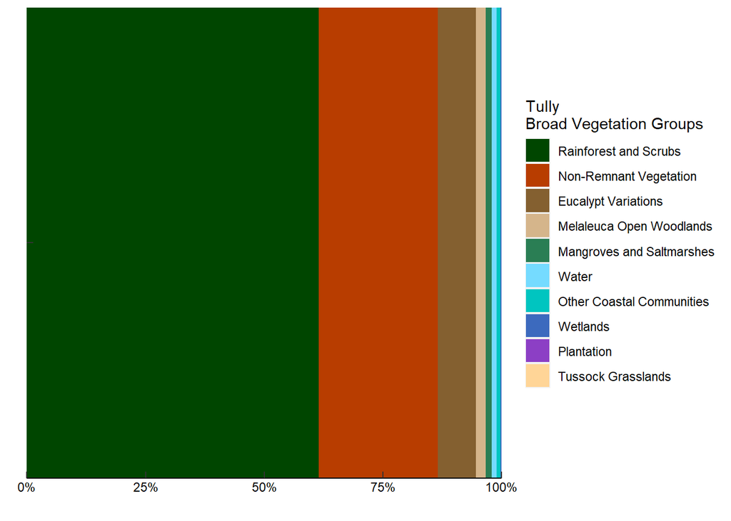

```r
plot
```

## 5.2 Basin Maps

We will then create the basin and sub basin maps, obviously these require spatial information and thus we will be using the spatial version of the dataset here. Again we need to create a custom palette however the method of implementation is slightly different as a different R package is used.

```r
#and an empty column to hold palette
bvg_map_data$palette <- NA

for (i in 1:length(my_palette)){#for the length of the palette, match each element

  #using the custom palette we created earlier
  bvg_map_data <- bvg_map_data |> mutate(palette = case_when(vegetation == names(my_palette)[i] ~ my_palette[[i]],
                                                             T ~ palette))
}
```

Then we will create the maps, looping for each basin. Note that the way the palette works this time is by having a specific row in the dataset that it used to colour each group.

```r
#drop environment out of the n3 region dataset (just creates unnecessary clutter)
n3_region <- n3_region |>
  group_by(region, basin, sub_basin) |> summarise(geom = st_union(geom)) |>
  ungroup() |> st_cast() |> st_make_valid()

#list out sub basins
sub_basins <- unique(n3_region$sub_basin)

#note we are using the target_year variable created earlier
for (i in sub_basins){#for each basin

  #select basin from vegetation data
  target_sub_basin <- bvg_map_data |> filter(sub_basin == i, year == target_year)

  #check if data is empty
  if (nrow(target_sub_basin) != 0){

    #get the basin outline from the n3 region dataset
    sub_basin_outline <- n3_region |> filter(sub_basin == i)

    #get the region correct region
    region_outline <- n3_region |> filter(region == unique(sub_basin_outline$region))

    #create a bbox of the vegetation data
    veg_bbox <- st_as_sfc(st_bbox(target_sub_basin))

    #create an inset map
    inset_map <- tm_shape(qld) +
      tm_polygons(col = "grey80", border.col = "black") +
      tm_shape(region_outline, is.master = T) +
      tm_polygons(col = "grey90", border.col = "black") +
      tm_shape(veg_bbox) +
      tm_borders(lwd = 2, col = "red")

    #create a map of the area
    map <- tm_shape(qld) +
      tm_polygons(col = "grey80", border.col = "black") +
      tm_shape(sub_basin_outline) +
      tm_polygons(col = "grey90", border.col = "black") +
      tm_shape(target_sub_basin, is.master = T) +
      tm_fill(col = "palette") +
      tm_add_legend(type = "fill", col = unique(target_sub_basin$palette), labels = unique(target_sub_basin$vegetation)) +
      tm_shape(sub_basin_outline) +
      tm_borders(col = "black") +
      tm_layout(legend.frame = T, legend.bg.color = "White", asp = 1.1,
                legend.text.size = 0.7, legend.position = c("left", "bottom")) +
      tm_scale_bar(width = 0.15, text.size = 0.7, position = c(0.3, 0))

    #figure out the aspect of the inset map and the view port
    xy <- st_bbox(region_outline)
    asp2 <- (xy$ymax - xy$ymin)/(xy$xmax - xy$xmin)
    w <- 0.2
    h <- asp2 * w
    vp <- viewport(x = 0.985, y = 0.97, width = w, height = h, just = c("right", "top"))

    #edit names
    edit_i <- str_remove_all(str_to_lower(paste(i, target_year, sep = "_")), "_map")

    #save the map as a png
    tmap_save(map, filename = glue("{save_path}/maps/{edit_i}_broad_vegetation_groups_map.png"),
              insets_tm = inset_map, insets_vp = vp)


    if (unique(target_sub_basin$sub_basin) != unique(target_sub_basin$basin)){#if sub basin != basin

      #figure out what the basin actually is
      actual_basin <- unique(target_sub_basin$basin)

      #edit name for file editing
      basin_name <- str_replace_all(str_to_lower(actual_basin), " ", "_")

      if (!file.exists(glue("{save_path}/maps/{basin_name}_basin_broad_vegetation_groups_map.png"))){

        #select basin from vegetation data
        target_basin <- bvg_map_data |> filter(basin == actual_basin)

        #get the basin outline from the n3 region dataset
        basin_outline <- n3_region |> filter(basin == actual_basin)

        #get the region correct region
        region_outline <- n3_region |> filter(region == unique(basin_outline$region))

        #create a bbox of the vegetation data
        veg_bbox <- st_as_sfc(st_bbox(target_basin))

        #create an inset map
        inset_map <- tm_shape(qld) +
          tm_polygons(col = "grey80", border.col = "black") +
          tm_shape(region_outline, is.master = T) +
          tm_polygons(col = "grey90", border.col = "black") +
          tm_shape(veg_bbox) +
          tm_borders(lwd = 2, col = "red")

        #create a map of the area
        map <- tm_shape(qld) +
          tm_polygons(col = "grey80", border.col = "black") +
          tm_shape(basin_outline) +
          tm_polygons(col = "grey90", border.col = "black") +
          tm_shape(target_basin, is.master = T) +
          tm_fill(col = "palette") +
          tm_add_legend(type = "fill", col = unique(target_basin$palette), labels = unique(target_basin$vegetation)) +
          tm_shape(basin_outline) +
          tm_borders(col = "black") +
          tm_layout(legend.frame = T, legend.bg.color = "White", asp = 1.1,
                    legend.text.size = 0.7, legend.position = c("left", "bottom")) +
          tm_scale_bar(width = 0.15, text.size = 0.7, position = c(0.3, 0))

        #figure out the aspect of the inset map and the view port
        xy <- st_bbox(region_outline)
        asp2 <- (xy$ymax - xy$ymin)/(xy$xmax - xy$xmin)
        w <- 0.2
        h <- asp2 * w
        vp <- viewport(x = 0.985, y = 0.97, width = w, height = h, just = c("right", "top"))

        #save the map as a png
        tmap_save(map, filename = glue("{save_path}/maps/{basin_name}_basin_broad_vegetation_groups_map.png"),
                  insets_tm = inset_map, insets_vp = vp)

      }
    }
  }
}
```

Here is an example of how one of the maps looks, noting that the actual outputted version looks much nicer.

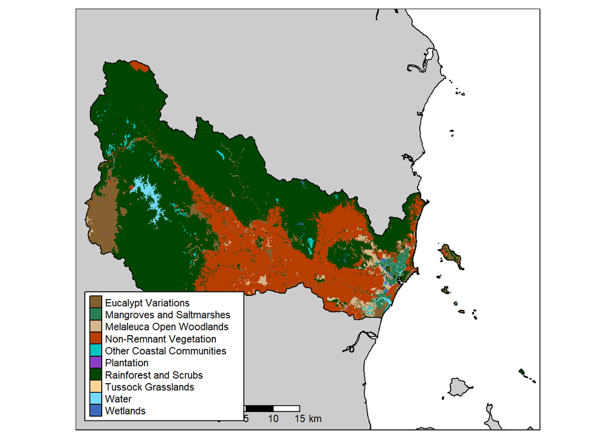

```r
map
```

## 5.3 Vegetation Over Time

Lastly we want to look at how the total amount of vegetation has changed over time. We will be using the percent change column in the table version to explore this.

```r
#list out sub_basins
sub_basins <- unique(n3_region$sub_basin)

for (i in sub_basins){

  #divide percent by 100 to correct for unit addition under 'scale_x_continuous()'
  #drop remnant from year names
  target_data <- bvg_tbl_data |> filter(sub_basin == i) |>
    group_by(region, basin, sub_basin, year, vegetation) |> summarise(y_on_y_percentage_change = sum(y_on_y_percentage_change)) |>
    ungroup() |>
    mutate(y_on_y_percentage_change = y_on_y_percentage_change/100) |>
    mutate(year = str_remove_all(year, "remnant_"))

  #check if data is empty
  if (nrow(target_data) != 0){

    #change year to a factor to get the order right
    target_data <- target_data |> mutate(year = factor(year, levels = unique(target_data$year)))

    #plot
    plot <- ggplot(target_data, aes(y_on_y_percentage_change, year, fill = vegetation)) +
      geom_bar(stat = "identity", position = "dodge") +
      scale_y_discrete(limits = rev) +
      scale_fill_manual(values = my_palette) +
      scale_x_continuous(labels = scales::percent_format(accuracy = 0.1)) +
      theme(axis.text.x = element_text(colour = "black"),
            axis.line.x = element_line(colour = "black"),
            axis.text.y = element_text(colour = "black"),
            axis.line.y = element_line(colour = "black"),
            axis.ticks.y = element_blank(),
            panel.background = element_blank()) +
      geom_vline(xintercept = 0) +
      geom_hline(yintercept = seq(1.5, length(unique(target_data$year))-0.5, 1),
                 lwd = 0.5, colour = "grey80") +
      labs(x = "Year on Year Change (%)", y = "Year", fill = glue("{i}\nBroad Vegetation Groups"))

    #edit names
    edit_i <- str_replace_all(str_to_lower(i), " ", "_")

    #save
    ggsave(glue("{save_path}/plots/{edit_i}_broad_vegetation_groups_change-over-time.png"), plot)

    if (unique(target_data$sub_basin) != unique(target_data$basin)){#if sub basin != basin

      #figure out what the basin actually is
      actual_basin <- unique(target_data$basin)

      #edit name for file editing
      basin_name <- str_replace_all(str_to_lower(actual_basin), " ", "_")

      if (!file.exists(glue("{save_path}/plots/{basin_name}_basin_broad_vegetation_groups_change-over-time.png"))){

        #divide percent by 100 to correct for unit addition under 'scale_x_continuous()'
        #drop remnant from year names
        target_data <- bvg_tbl_data |> filter(basin == actual_basin) |>
          group_by(region, basin, year, vegetation) |> summarise(y_on_y_percentage_change = sum(y_on_y_percentage_change)) |>
          ungroup() |>
          mutate(y_on_y_percentage_change = y_on_y_percentage_change/100) |>
          mutate(year = str_remove_all(year, "remnant_"))

        #change year to a factor to get the order right
        target_data <- target_data |> mutate(year = factor(year, levels = unique(target_data$year)))

        #plot
        plot <- ggplot(target_data, aes(y_on_y_percentage_change, year, fill = vegetation)) +
          geom_bar(stat = "identity", position = "dodge") +
          scale_y_discrete(limits = rev) +
          scale_fill_manual(values = my_palette) +
          scale_x_continuous(labels = scales::percent_format(accuracy = 0.1)) +
          theme(axis.text.x = element_text(colour = "black"),
                axis.line.x = element_line(colour = "black"),
                axis.text.y = element_text(colour = "black"),
                axis.line.y = element_line(colour = "black"),
                axis.ticks.y = element_blank(),
                panel.background = element_blank()) +
          geom_vline(xintercept = 0) +
          geom_hline(yintercept = seq(1.5, length(unique(target_data$year))-0.5, 1),
                     lwd = 0.5, colour = "grey80") +
          labs(x = "Year on Year Change (%)", y = "Year", fill = glue("{actual_basin} Basin\nBroad Vegetation Groups"))

        #save
        ggsave(glue("{save_path}/plots/{basin_name}_basin_broad_vegetation_groups_change-over-time.png"), plot)

      }
    }
  }
}
```

Here is an example of how one of the change over time plots looks, noting that the actual outputted version looks much nicer.

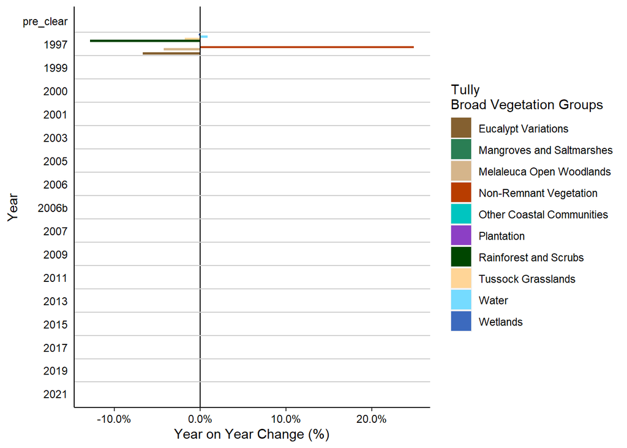

```r
plot
```

And that is everything, script complete.

# 6 Session Info

Below is the session info at the time of rendering this script. Of greatest importance is to note the R version, and the “other attached packages” as these are the most significant drivers of success/failure. It is also good to check the “attached base packages” and “loaded via a namespace” packages as well. To check your session info use `sessionInfo()`.

[session information not shown]